# Problema 4 - Checkpoint 1

O GitHub é uma plataforma online de código-fonte e controle de versão. Nela inúmeros programadores disponibilizam seus projetos de código aberto para que toda a comunidade possa utilizá-los e melhorá-los.

Como deve-se imaginar, esse serviço contém uma grande quantidade de projetos, escrito em diferentes linguagens de programação. Neste trabalho, vamos analisar um pouco o comportamento dos usuários do GitHub. Para isso, foi colhido uma amostra dos dados. Como a quantidade de informação é muito grande, optamos por pegar uma quantidade reduzida para facilitar a análise.

Cada observação no dataset representa o dado de um conjunto de commits em determinado dia do ano. A observação é composta por: Linguagem de Programação (facilmente podemos inferir através da extensão do arquivo), data e número de usuários que deram commit naquela linguagem naquele dia.

As linguagens de programação disponíveis no dataset são:

```r
unique(dados$file_extension) %>%
  sort()
```

```
 [1] c       cc      config  cpp     cs      csproj  css     eot     gif     go      gradle  h       html    ico
[15] java    jpg     js      json    less    lock    m       map     md      pbxproj pdf     php     png     py
[29] rb      rst     scss    sh      sql     svg     swift   ts      ttf     txt     woff    xml     yaml    yml
42 Levels: c cc config cpp cs csproj css eot gif go gradle h html ico java jpg js json less lock m map ... yml
```

Como é possível ver, algumas extensões disponíveis no dataset não são de programação. Na nossa análise, levaremos em consideração duas linguagens de programação para responder as seguintes perguntas: 1 - Para cada uma delas, há uma diferença significativa na sua popularidade durante a semana e durante o fim de semana? Essa diferença é grande? 2 - Existe uma diferença significativa entre as duas linguagens na sua variação de popularidade nos finais de semana?

As linguagens escolhidas são: Java e Python.

```r
pyva = dados %>%
  filter(file_extension %in% c("java", "py"))
pyva$date <- paste(pyva$month_day,pyva$the_month, pyva$the_year, sep = "-")
pyva = pyva %>%
  mutate(weekday = weekdays(as.Date(date,'%d-%m-%Y')))
pyva = pyva %>%
  mutate(isFDS = weekday %in% c("domingo", "sabado"))
pyva.java = pyva %>%
  filter(file_extension == "java")
pyva.python = pyva %>%
  filter(file_extension == "py")
```

Como nossos dados são apenas uma amostra do universo total de commits no github, vamos utilizar uma técnica chamada bootstrapping. O bootstrapping é um método de reamostragem utilizado para aproximar distribuição na amostra de um levantamento estatístico.

```r
medianas.java <- bootstrap2(pyva.java$users, treatment = pyva.java$isFDS, median,R = 10000)
medianas.java.ci <- CI.percentile(medianas.java, probs = c(.025, .975))
```

```r
medianas.python <- bootstrap2(pyva.python$users, treatment = pyva.python$isFDS, median,R = 10000)
medianas.python.ci <- CI.percentile(medianas.python, probs = c(.025, .975))
```

Para responder a primeira questão, vamos analisar o intervalo de confiança das medianas entre o desenvolvimento nas linguagens escolhidas no durante a semana e no final dela.

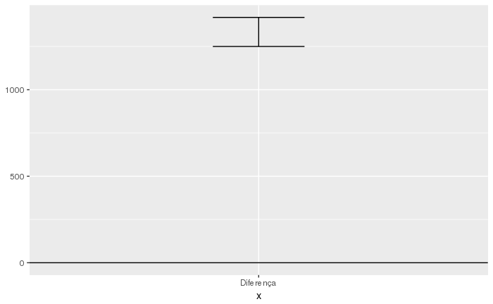

```r
data.frame(medianas.java.ci) %>%
  ggplot(aes(x = "Diferença", ymin = X2.5., ymax = X97.5.)) +
  geom_errorbar(width = .2) +
  geom_hline(yintercept = 0)
```

O gráfico acima se refere ao intervalo de confiança do quesito levantado acima para a linguagem Java. Com 95% de certeza (garantidos a partir do bootsrapping), é possível afirmar que o intervalo das medianas é (1248, 1420). Esse é um valor relativamente alto perante os usuários da linguagem Java. Com isso, podemos dizer que há uma relevante diferença entre o uso de Java durante a semana e no final.

Para Python:

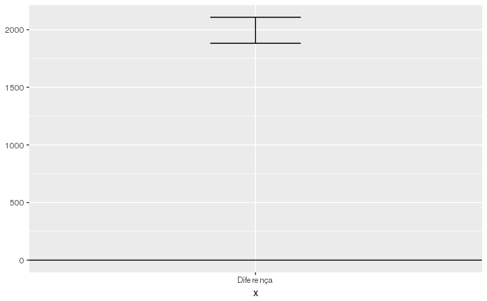

```r
data.frame(medianas.python.ci) %>%
  ggplot(aes(x = "Diferença", ymin = X2.5., ymax = X97.5.)) +
  geom_errorbar(width = .2) +
  geom_hline(yintercept = 0)
```

Para responder a pergunta 2, estamos interessados apenas nos commits realizados no final de semana. Vamos tratar nossos dados para considerar apenas esse subconjunto.

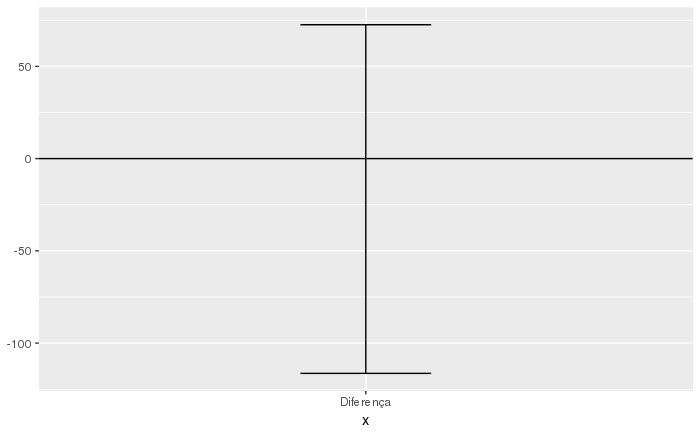

```r
medianas.diff <- bootstrap2(data = (pyva.java %>% filter(isFDS == TRUE))$users,
               data2 = (pyva.python %>% filter(isFDS == TRUE))$users,
               sd)
medianas.diff.ci = CI.percentile(medianas.diff, probs = c(.025, .975))
data.frame(medianas.diff.ci) %>%
  ggplot(aes(x = "Diferença", ymin = X2.5., ymax = X97.5.)) +
  geom_errorbar(width = .2) +
  geom_hline(yintercept = 0)
```

Como o intervalo de confiança inclui o 0, não pode-se concluir que existe uma variação nos commits do final de semana entre Python e Java.